# Forecasting Time Series

Daniel Jeffry

10/20/2021

# Description

This reports provides material forecasting demand using Arima, Exponential Smoothing, Croston, and Syntetos Boyland Approximation method. The dataset using in this report for modeling is real case data in one of the state owned company in Indonesia.

The report as structured as follows:  
1. Data Extraction  
2. Exploratory Data Analysis  
3. Data Preparation  
4. Modeling  
5. Evaluation  
6. Recommendation

# 1. Data Extraction

Import necessary libraries.

```r
library(readxl)
library(tidyverse)
library(fpp3)
library(dplyr)
library(gridExtra)
library(flexclust)
```

Library **readlxl**: for import excel files into R.  
Library **tidyverse**: for select unique/distinct rows from data frame.  
Library **fpp3**: for visualization of correlation coefficient matrix  
Library **gridExtra**: for plotting multiple graphs. Library **caret**: for One Hod Encoding

For the next step, we can load the data and selecting relevant columns. Then, see the dataframe’s structure.

```r
dt2 <- read_excel("Data/Data Kerja Praktik.XLSX", sheet = "FINAL", skip = 1) %>%
  select("material" = `Short text`, "harga" = Harga, "tingkat_kekritisan" = `Tingkat kekritisan`, "rutin_nonrutin" = `Rutin/Non Rutin`, Jan:Des, `2014`:`2018`, `2019` = `2019...30`, "ROQ" = ROQ)
dt2 <- dt2[2:(nrow(dt2)-2),]

dt <- dt2 %>%
  group_by(material) %>%
  distinct(material, .keep_all = T)

str(dt)
```

```
## grouped_df [1,861 x 23] (S3: grouped_df/tbl_df/tbl/data.frame)
##  $ material          : chr [1:1861] "CABLE PWR;NYAF;1X4mm2;0.6/1kV;OH" "INVERTER;;380/500V;3P;0.75KW" "INVERTER;;380/480VAC;6P;15KW" "INVERTER;;380/480VAC;6P;5.5KW" ...
##  $ harga             : num [1:1861] 380000 3153700 47000000 22000000 34500000 ...
##  $ tingkat_kekritisan: chr [1:1861] "C" "C" "C" "C" ...
##  $ rutin_nonrutin    : chr [1:1861] "NON RUTIN" "NON RUTIN" "NON RUTIN" "NON RUTIN" ...
##  $ Jan               : num [1:1861] 0 0 0 0 1 0 0 0 0 0 ...
##  $ Peb               : num [1:1861] 0 0 0 0 0 0 0 0 0 0 ...
##  $ Mar               : num [1:1861] 0 0 0 0 0 0 0 0 0 0 ...
##  $ Apr               : num [1:1861] 0 0 0 0 0 0 0 0 0 0 ...
##  $ May               : num [1:1861] 0 0 0 0 7 0 0 0 0 0 ...
##  $ Jun               : num [1:1861] 0 0 0 0 0 0 0 0 0 0 ...
##  $ Jul               : num [1:1861] 0 0 0 0 0 0 0 0 0 0 ...
##  $ Aug               : num [1:1861] 0 0 0 0 3 0 0 0 0 0 ...
##  $ Sep               : num [1:1861] 0 0 0 0 0 0 0 0 0 0 ...
##  $ Okt               : num [1:1861] 0 0 0 0 0 0 0 0 0 0 ...
##  $ Nop               : num [1:1861] 0 0 0 0 0 0 0 0 0 0 ...
##  $ Des               : num [1:1861] 0 0 0 0 0 0 0 0 0 0 ...
##  $ 2014              : num [1:1861] 0 4 0 0 0 0 0 0 0 0 ...
##  $ 2015              : num [1:1861] 0 0 0 0 0 0 0 0 0 0 ...
##  $ 2016              : num [1:1861] 3 0 2 2 0 0 0 0 3 0 ...
##  $ 2017              : num [1:1861] 0 0 0 0 0 0 0 0 0 3 ...
##  $ 2018              : num [1:1861] 0 0 0 0 0 0 0 0 0 0 ...
##  $ 2019              : num [1:1861] 0 0 0 0 1 0 0 0 0 0 ...
##  $ ROQ               : num [1:1861] 0 0 0 0 6.08 ...
##  - attr(*, "groups")= tibble [1,861 x 2] (S3: tbl_df/tbl/data.frame)
##   ..$ material: chr [1:1861] "ACTUATOR ACC;POSITIONER SIPART PS2" "ACTUATOR;AUM;SA075AM011;GS1003" "ACTUATOR;AUM;SA075AM011GF1003;" "ACTUATOR;CCI;FFWCV;85104503" ...
##   ..$ .rows   : list<int> [1:1861]
##   .. ..$ : int 602
##   .. ..$ : int 237
##   .. ..$ : int 249
##   .. ..$ : int 149
##   .. ..$ : int 142
##   .. ..$ : int 136
##   .. ..$ : int 239
##   .. ..$ : int 947
##   .. ..$ : int 432
##   .. ..$ : int 358
##   .. ..$ : int 433
##   .. ..$ : int 434
##   .. ..$ : int 584
```

[output cut: 74 more lines]

[output not shown]

The dataset has 1861 observations and 23 variables.

# 2. Exploratory Data Analysis

After in the previous stage we can find out the conclusions from each column, then we can further analyze it using exploratory data analysis (EDA) techniques. The purpose of this EDA stage is to be able to find out information more clearly and efficiently through graph plots of the data to be predicted.

```r
dt2$tingkat_kekritisan <- as.factor(dt2$tingkat_kekritisan)
dt2$rutin_nonrutin <- as.factor(dt2$rutin_nonrutin)
dt2$tingkat_kekritisan[dt2$tingkat_kekritisan == "c"]
```

```
##  [1] <NA> <NA> c    <NA> <NA> <NA> <NA> <NA> <NA> <NA> <NA> <NA> <NA> <NA> <NA>
## [16] <NA> <NA> <NA> <NA> <NA> <NA> <NA> <NA> <NA> <NA> <NA> <NA> <NA> <NA> <NA>
## [31] <NA> <NA> <NA> <NA> <NA> <NA> <NA> <NA> <NA> <NA> <NA> <NA> <NA> <NA> <NA>
## [46] <NA> <NA> <NA> <NA> <NA> <NA> <NA> <NA> <NA> <NA>
## Levels: A B c C
```

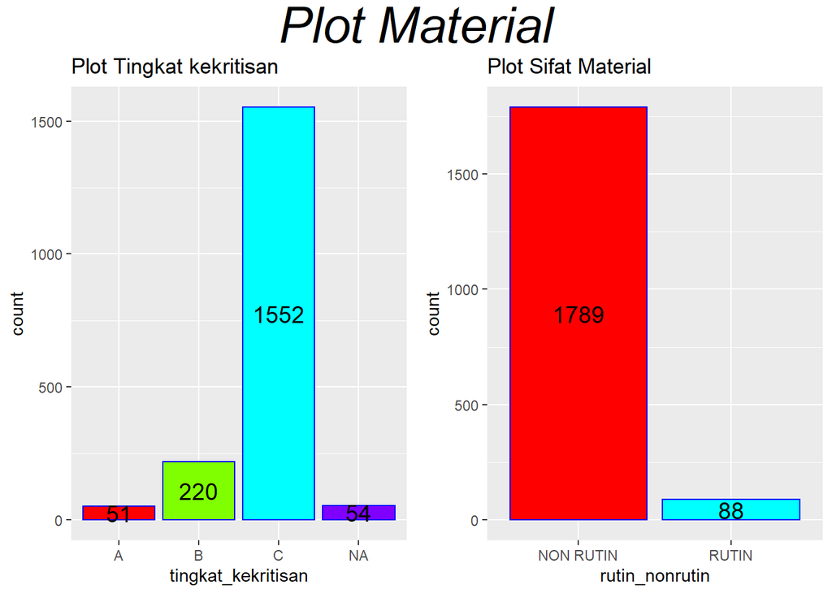

```r
dt2 <- dt2 %>%
  mutate(tingkat_kekritisan =
           replace(tingkat_kekritisan,
                   tingkat_kekritisan == "c",
                   "C"))
p1a <- ggplot(data=dt2, aes(x = tingkat_kekritisan)) +
  geom_bar(fill = rainbow(4),
           color = "blue")+
  stat_count(geom = "text", color = "black", size = 5,
             aes(label = ..count..), position=position_stack(vjust = 0.5)) +
  labs(title = "Plot Tingkat kekritisan")
p2a <- ggplot(data=dt2, aes(x = rutin_nonrutin)) +
  geom_bar(fill = rainbow(2),
           color = "blue")+
  stat_count(geom = "text", color = "black", size = 5,
             aes(label = ..count..), position=position_stack(vjust = 0.5)) +
  labs(title = "Plot Sifat Material")

plot_sifat <- grid.arrange(p1a, p2a, ncol = 2,
                           top=textGrob("Plot Material",gp=gpar(fontsize=30,font=3)))
```

Plot visual data on the classification and properties of materials based on material list data. Seen in the classification of materials, materials with a criticality level of C have a greater number, of which there are 1552 materials and based on their nature, non-routine materials have more quantities than non-routine ones. There are 1789 non-routine materials and 88 routine materials. In 2020, there are 1737 non-routine materials and 88 routine materials.

# 3. Data Preparation

After going through the process of cleaning and merging data, the next preprocessing stage is to transform the data. This process is used to convert the previous data format into the desired format in the model.

```r
yearly <- dt %>%
  select(material, `2014`:`2019`) %>%
  pivot_longer(`2014`:`2019`, names_to = "tahun", values_to = "n") %>%
  mutate(tahun = as.integer(tahun)) %>%
  arrange(tahun, material) %>%
  distinct(tahun, material, .keep_all = T) %>%
  as_tsibble(index = tahun, key = material)
```

# 4. Modelling

The modeling stage will discuss the model that will be used for forecasting. The transformed material data will be divided first into training data and test data. Training data is data that we build to train the algorithm to make predictions that later the program can read patterns based on the data provided. Test data is data given to test the results of predicted values to measure the accuracy of values based on actual data.

## 4.1 Generate Test Design

Training data is the usage rate taken in the 2014-2018 period. As for the test data, the total usage rate will be taken in 2019. After the data is distributed, the total training data consists of 9305 observations and the test data has 1861 observation data.

```r
# Split training = 6, test = 1 ----
train_ts <- yearly %>%
  group_by_key(material) %>%
  slice(1:5)
test_ts <- yearly %>%
  group_by_key(material) %>%
  slice(6)

train_ts
```

```
## # A tsibble: 9,305 x 3 [1Y]
## # Key:       material [1,861]
## # Groups:    material [1,861]
##    material                           tahun     n
##    <chr>                              <int> <dbl>
##  1 ACTUATOR ACC;POSITIONER SIPART PS2  2014    12
##  2 ACTUATOR ACC;POSITIONER SIPART PS2  2015     1
##  3 ACTUATOR ACC;POSITIONER SIPART PS2  2016     0
##  4 ACTUATOR ACC;POSITIONER SIPART PS2  2017     1
##  5 ACTUATOR ACC;POSITIONER SIPART PS2  2018     0
##  6 ACTUATOR;AUM;SA075AM011;GS1003      2014     0
##  7 ACTUATOR;AUM;SA075AM011;GS1003      2015     0
##  8 ACTUATOR;AUM;SA075AM011;GS1003      2016     2
##  9 ACTUATOR;AUM;SA075AM011;GS1003      2017     0
## 10 ACTUATOR;AUM;SA075AM011;GS1003      2018     0
## # ... with 9,295 more rows
```

```r
test_ts
```

```
## # A tsibble: 1,861 x 3 [1Y]
## # Key:       material [1,861]
## # Groups:    material [1,861]
##    material                           tahun     n
##    <chr>                              <int> <dbl>
##  1 ACTUATOR ACC;POSITIONER SIPART PS2  2019     7
##  2 ACTUATOR;AUM;SA075AM011;GS1003      2019     0
##  3 ACTUATOR;AUM;SA075AM011GF1003;      2019     0
##  4 ACTUATOR;CCI;FFWCV;85104503         2019     0
##  5 ACTUATOR;CCI;MFWCV;30202002SOFT     2019     0
##  6 ACTUATOR;CCI;TBPVALE;500RMSOFT      2019     0
##  7 ACTUATOR;CDC;63000604D3;PSLG15      2019     0
##  8 ACTUATOR;EOM;63000604D3;ED0100      2019    12
##  9 ACTUATOR;MOTOR;;213050413           2019     0
## 10 ACTUATOR;MOTOR;A0000012A;48RPM      2019     0
## # ... with 1,851 more rows
```

The transformation of the data entered into the dataframe (yearly) is then divided to determine the training data and test data used for testing. In the training data there are 5 points of request time, while the test data has 1 point of request time.

## 4.2 Build Model

The methods used in this forecasting are Croston method, Syntetos Boyland Approximation, Arima and Exponential Smoothing. These four models will predict the value of training which will automatically learn the pattern of data movement for each material.

```r
# Fitting Model ----
model_fit <- train_ts %>%
  model(
    croston = CROSTON(n, type = "croston"),
    sba = CROSTON(n, type = "sba"),
    arima = ARIMA(n),
    ets = ETS(n)
  )
model_fit
```

```
## # A mable: 1,861 x 5
## # Key:     material [1,861]
##    material                     croston          sba          arima          ets
##    <chr>                        <model>      <model>        <model>      <model>
##  1 ACTUATOR ACC;POSITIONE~    <croston>    <croston> <ARIMA(0,0,0)> <ETS(A,N,N)>
##  2 ACTUATOR;AUM;SA075AM01~ <NULL model> <NULL model> <ARIMA(0,0,0)> <ETS(A,N,N)>
##  3 ACTUATOR;AUM;SA075AM01~ <NULL model> <NULL model> <ARIMA(0,0,0)> <ETS(A,N,N)>
##  4 ACTUATOR;CCI;FFWCV;851~ <NULL model> <NULL model> <ARIMA(0,0,0)> <ETS(A,N,N)>
##  5 ACTUATOR;CCI;MFWCV;302~ <NULL model> <NULL model> <ARIMA(0,0,0)> <ETS(A,N,N)>
##  6 ACTUATOR;CCI;TBPVALE;5~ <NULL model> <NULL model> <ARIMA(0,0,0)> <ETS(A,N,N)>
##  7 ACTUATOR;CDC;63000604D~ <NULL model> <NULL model> <ARIMA(0,0,0)> <ETS(A,N,N)>
##  8 ACTUATOR;EOM;63000604D~ <NULL model> <NULL model> <ARIMA(0,0,0)> <ETS(A,N,N)>
##  9 ACTUATOR;MOTOR;;213050~ <NULL model> <NULL model> <ARIMA(0,0,0)> <ETS(A,N,N)>
## 10 ACTUATOR;MOTOR;A000001~ <NULL model> <NULL model> <ARIMA(0,0,0)> <ETS(A,N,N)>
## # ... with 1,851 more rows
```

```r
# Filter material dengan nilai null pada semua model ----
not_null_model <- model_fit %>%
  filter(!is_null_model(sba) | !is_null_model(croston) |
           !is_null_model(arima) | is_null_model(ets))

# Menghitung Akurasi ----
akurasi <- forecast(not_null_model, h = 2) %>%
  accuracy(test_ts) %>%
  select(.model, material, RMSE)
akurasi_summary <- akurasi %>%
  na.omit() %>%
  group_by(.model) %>%
  summarise(RMSE_mean = mean(RMSE))

dt_prep <- dt %>%
  select(1, "harga" = 2, "tingkat_kekritisan" = 3, "rutin_nonrutin" = 4, "2019" = 22, "ROQ" = 23)
```

```r
# Menghitung nilai ramalan ----
peramalan <- forecast(not_null_model, h = 2)

# Tabel report ----
t1 <- peramalan %>%
  as_tibble() %>%
  filter(tahun == 2020) %>%
  mutate(prediksi_2020 = paste0(.model, "_", as.character(tahun))) %>%
  select(material, .mean, prediksi_2020) %>%
  pivot_wider(names_from = prediksi_2020, values_from = .mean)

t2 <- akurasi %>%
  select(.model, material, RMSE) %>%
  pivot_longer(RMSE, names_to = "matriks", values_to = "nilai_akurasi") %>%
  mutate(model_akurasi = paste0(.model, "_", matriks)) %>%
  select(material, nilai_akurasi, model_akurasi) %>%
  pivot_wider(names_from = model_akurasi, values_from = nilai_akurasi)
```

```r
# Memasukkan 4 model dan memilih model yang terbaik
## Memasukkan data peramalan yang sudah dibersihkan di Excel
dt_prep <- read_excel("Data/dt_prep.xlsx")

akurasi2 <- dt_prep %>%
  select(material, ROQ.e) %>%
  na.omit() %>%
  pivot_longer(ROQ.e, names_to = ".model", values_to = "RMSE") %>%
  bind_rows(akurasi) %>%
  group_by(.model)

akurasi3 <- akurasi2 %>%
  group_by(material) %>%
  slice_min(order_by = RMSE, n = 1)

akurasi2 %>%
  group_by(material) %>%
  slice_min(order_by = RMSE, n = 1) %>%
  ungroup() %>%
  distinct(material, .keep_all = TRUE) %>%
  summarise(mean(RMSE))
```

```
## # A tibble: 1 x 1
##   `mean(RMSE)`
##          <dbl>
## 1         5.03
```

```r
metode_optimal <- akurasi2 %>%
  group_by(material) %>%
  slice_min(order_by = RMSE, n = 1) %>%
  ungroup() %>%
  distinct(material, .keep_all = TRUE)
```

The report table contains the optimal model for forecasting materials. The optimal model is determined based on the smallest error value in each forecast tested based on demand data in 2019.

```r
nilai_3_peramalan <- dt_prep %>%
  select(material, ROQ) %>%
  left_join(t1)
nilai_3_peramalan$ROQ <- as.numeric(nilai_3_peramalan$ROQ)
nilai_3_peramalan %>%
  pivot_longer(cols = 2:6, names_to = ".model", values_to = "nilai_prediksi") %>%
  right_join(metode_optimal, by = c("material", ".model")) %>%
  ungroup() %>%
  arrange(.model)
```

```
## # A tibble: 1,861 x 4
##    material                             .model nilai_prediksi  RMSE
##    <chr>                                <chr>           <dbl> <dbl>
##  1 ACTUATOR;AUM;SA075AM011GF1003;       arima              NA     0
##  2 ACTUATOR;CDC;63000604D3;PSLG15       arima              NA     0
##  3 ACTUATOR;MOTOR;A0000012A;48RPM       arima              NA     0
##  4 BOILER ACC;IVC ROD END LINKAGE       arima              NA     2
##  5 BOILER ACC;TUBE 64X6X7000MM SA210-A1 arima              NA     0
##  6 BOILER ACC;TUBE SUPERHEAT GB12       arima              NA    15
##  7 BOLT&NUT;FUJ;M64X;ST114051AP2P       arima              NA     0
##  8 BUSH;DMW;VPFCM;R233                  arima              NA     0
##  9 CHEM;ANTISCALANT RO;PC 191 T         arima              NA    90
## 10 CHEM;HYDROCHLORIC ACID;32%           arima              NA   960
## # ... with 1,851 more rows
```

```r
result_forecast <- nilai_3_peramalan %>%
  pivot_longer(cols = 2:6, names_to = ".model", values_to = "nilai_prediksi") %>%
  mutate(
    .model = str_remove(.model, "_2020"),
    .model = str_replace(.model, "ROQ", "ROQ.e")) %>%
  right_join(metode_optimal, by = c("material", ".model")) %>%
  ungroup() %>%
  arrange(.model)

colSums(is.na(result_forecast))
```

```
##       material         .model nilai_prediksi           RMSE
##              0              0              0              0
```

```r
nrow(nilai_3_peramalan)
```

```
## [1] 1861
```

```r
nrow(metode_optimal)
```

```
## [1] 1861
```

```r
colSums(is.na(result_forecast))
```

```
##       material         .model nilai_prediksi           RMSE
##              0              0              0              0
```

```r
result_forecast2 <- result_forecast %>%
  left_join(dt_prep) %>%
  select(material, harga, tingkat_kekritisan, ROQ, rutin_nonrutin, `2019`,
         starts_with(".model"), starts_with("nilai_prediksi"))
result_forecast2 <- result_forecast2 %>%
  mutate(ROQ =
           replace(ROQ,
                   is.na(result_forecast2$ROQ),
                   "0"))
result_forecast2$ROQ <- as.numeric(result_forecast2$ROQ)
result_forecast2$harga <- as.numeric(result_forecast2$harga)
result_forecast2$nilai_prediksi <- ceiling(result_forecast2$nilai_prediksi)
result_forecast2$ROQ <- ceiling(result_forecast2$ROQ)
```